# HOMEWORK

# 9.7. (2 points) Use your recommended number of trees and mtry value to build a new random forest classifier using train_data.

```r
rf <-randomForest(gen_election~., data=train, mtry=5, importance=TRUE, ntree=50)
print(rf)
```

```
##
## Call:
##  randomForest(formula = gen_election ~ ., data = train, mtry = 5,      importance = TRUE, ntree = 50)
##                Type of random forest: classification
##                      Number of trees: 50
## No. of variables tried at each split: 5
##
##         OOB estimate of  error rate: 6.15%
## Confusion matrix:
##     L   W class.error
## L 324  25  0.07163324
## W  15 286  0.04983389
```

# 9.8. (8 points) Use library(caret) to create the confusion matrix for test_data. Fill out the confusion matrix in below. Use “W” as the value of option positive in confusionMatrix() function. Here is the code from class example in “R_model_evaluation.html”:

```r
library(e1071)
library(caret)
predicted_values <- predict(rf, test,type= "prob")
threshold <- 0.5
pred <- factor( ifelse(predicted_values[,2] > threshold, 1, 0) )
levels(test$gen_election)[2]
```

```
## [1] "W"
```

```r
levels(test$gen_election) <- list("0" = "L", "1" = "W")

str(pred)
```

```
##  Factor w/ 2 levels "0","1": 1 1 1 1 1 1 1 1 1 1 ...
##  - attr(*, "names")= chr [1:279] "2" "3" "4" "8" ...
```

```r
str(test$gen_election)
```

```
##  Factor w/ 2 levels "0","1": 1 1 1 1 1 1 1 1 1 1 ...
```

```r
confusionMatrix(pred, test$gen_election,
                positive = levels(test$gen_election)[2])
```

```
## Confusion Matrix and Statistics
##
##           Reference
## Prediction   0   1
##          0 138  11
##          1   7 123
##
##                Accuracy : 0.9355
##                  95% CI : (0.9, 0.9613)
##     No Information Rate : 0.5197
##     P-Value [Acc > NIR] : <2e-16
##
##                   Kappa : 0.8706
##
##  Mcnemar's Test P-Value : 0.4795
##
##             Sensitivity : 0.9179
##             Specificity : 0.9517
##          Pos Pred Value : 0.9462
##          Neg Pred Value : 0.9262
##              Prevalence : 0.4803
##          Detection Rate : 0.4409
##    Detection Prevalence : 0.4659
##       Balanced Accuracy : 0.9348
##
##        'Positive' Class : 1
##
```

[figure not shown]

```r
library(imager)
im <- load.image("C:/Users/Ibragim/Desktop/homework/Capture1.png")
plot(im)
```

## What is the value of accuracy? **0.93**

## What is the value of TPR? **0.91**

# 9.9. (4 points) Use the code in “R_model_evaluation.html” to calculate AUC and create the ROC curve.

```r
library(ROCR)
```

```r
library(ggplot2)

predicted_values_roc_rf <- predict(rf, test,type = "prob")[,2]
pred_roc_rf <- prediction(predicted_values_roc_rf, test$gen_election)
perf_rf <- performance(pred_roc_rf, measure = "tpr", x.measure = "fpr")
auc <- performance(pred_roc_rf, measure = "auc")
auc <- auc@y.values[[1]]
```

```r
roc.data <- data.frame(fpr=unlist(perf_rf@x.values),                       tpr=unlist(perf_rf@y.values), model="RF")
```

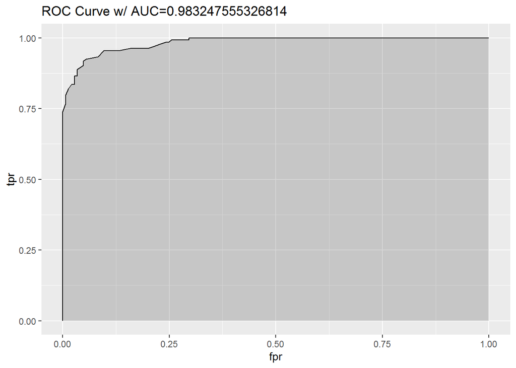

```r
ggplot(roc.data, aes(x=fpr, ymin=0, ymax=tpr)) +  geom_ribbon(alpha=0.2) +  geom_line(aes(y=tpr)) +  ggtitle(paste0("ROC Curve w/ AUC=", auc))
```

## What is the value of AUC? **0.98**

## Paste the ROC curve in the space below: **as u can see above picture shows**

# 9.10. (4 points) Use varImpPlot() to create the plot for variable importance. What are the type five important variables when we use MeanDecreaseAccuracy?

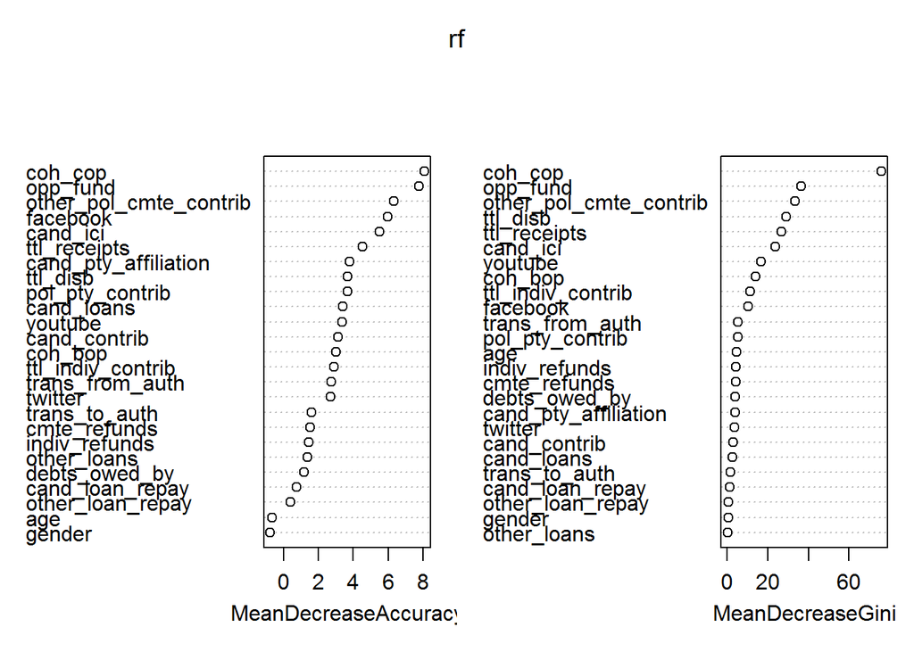

```r
varImpPlot(rf)
```

## What are the type five important variables when we use MeanDecreaseAccuracy? **facebook, coh_cop, opp_fund, other_pol_cmte_contrib, cand_ici**

[figure not shown]

```r
#in case the obove plot is not clearly seen
library(imager)
im <- load.image("C:/Users/Ibragim/Desktop/homework/Capture3.png")
plot(im)
```

```r
importance(rf)
```

```
##                                  L          W MeanDecreaseAccuracy
## twitter                 2.76998934  0.3391110            2.7137500
## facebook                4.47613523  5.0515961            5.9865416
## youtube                 2.89652216  2.7203386            3.3596522
## cand_ici                5.01019761  2.8339692            5.4969210
## cand_pty_affiliation    2.96280105  2.4228939            3.7875863
## ttl_receipts            3.66615872  3.1276444            4.5220597
## trans_from_auth         1.91076500  1.7624246            2.7283272
## ttl_disb                3.55558711  1.4013262            3.6859209
## trans_to_auth           1.22307978  0.5133250            1.5962460
## coh_bop                 2.49946703  2.8841261            3.0118711
## coh_cop                 6.28975522  6.7180961            8.0910352
## cand_contrib           -1.58178664  3.5575073            3.1119287
## cand_loans              1.96037803  2.5665121            3.4019072
## other_loans             0.00000000  1.3631301            1.3600224
## cand_loan_repay         0.45268720  0.5556950            0.7457842
## other_loan_repay       -1.01015254  1.0677300            0.3847614
## debts_owed_by          -0.07903239  2.0254677            1.1630371
## ttl_indiv_contrib       2.08924474  1.8001554            2.8832377
## other_pol_cmte_contrib  5.02868862  5.7689197            6.3468722
## pol_pty_contrib         2.48366478  2.6446821            3.6800368
## indiv_refunds          -0.61376086  2.3207999            1.4433716
## cmte_refunds            1.00804065  1.2854182            1.5114139
## opp_fund                6.47993017  6.7755498            7.7812328
## age                    -0.79237289  0.1027183           -0.6470915
## gender                  0.03960794 -0.7429699           -0.7769817
##                        MeanDecreaseGini
## twitter                       3.7067976
## facebook                     10.3670604
## youtube                      16.7603239
## cand_ici                     23.8498691
## cand_pty_affiliation          3.9073158
## ttl_receipts                 26.5805455
## trans_from_auth               5.4089495
## ttl_disb                     29.1583703
## trans_to_auth                 1.5016635
## coh_bop                      13.8617266
## coh_cop                      75.9583051
## cand_contrib                  2.9290186
## cand_loans                    2.4853762
## other_loans                   0.2717638
## cand_loan_repay               1.2021634
## other_loan_repay              0.6412954
## debts_owed_by                 3.9895519
## ttl_indiv_contrib            11.2168846
## other_pol_cmte_contrib       33.3013142
## pol_pty_contrib               5.1616319
## indiv_refunds                 4.3894700
## cmte_refunds                  4.2212219
## opp_fund                     36.4324675
## age                           4.6253012
## gender                        0.4582023
```

```r
library(nnet)
ann <- nnet(gen_election~ ., data=train, size=5, maxit=1000)
summary(ann)
```

[output not shown]